# Laboratory Slide Evaluations

## Analyses

### **READ ME**

##### **Information on “Analyses”**

**Click to View**

Within each tab is how your parameter evaluations compare to mine. Please note that your evaluation is compared to a range of values around my evaluation. My accepted ranges are narrower when my counts are low and wider when my counts are high

For example, if my WBC Est evaluation is 6.0, then I assess your evaluation as “Good” if you report a WBC estimate between 3 and 9. Values below my accepted range have a yellow label and values above a red label

For WBC Estimates, WBC Differentials, and PLT Estimates, I provide a “# SD”. This represents the number of standard deviations away from the accepted range mean. I define my accepted range as the mean plus/minus two standard deviations. Any reported value below/above 2 SD was marked as “Too Low”/“Too High”

Each parameter set is presented two ways. First, a summary of your “Individual” analysis of each parameter. Second, a summary of the “Class” frequencies for each parameter

“Inf SD” means I called zero and you called more than zero

Notice the analyses by cell types are separated by tabs (right under “Analyses” header)

##### **Instructor Slide Responses:**

Microcytic Anemias

- 89 N
  - WBC Estmate
    - Maybe we were in different areas of the monolayer…to explain why most students had high estimates. Review the virtual slides for areas I did my estimate
  - WBC Differential
    - Overall everyone did well; looks like some saw a few more eosinophils
  - WBC Morphology
    - I called toxic granulation
  - RBC Morphology
    - Overall, very close to normal in this patient
  - PLT Estimate
    - It is curious to me that many overestimated WBC but underestimated PLT; I don’t know…maybe platelets were hard to see?
- Micro/Hypo 3
  - WBC Estimate
    - Thumbs up
  - WBC Differential
    - I did not see any immature neutrophils
  - WBC Morphology
    - No hypersegs
    - No toxic gran (basophils are present, virtual slide Field 39, 61, 88)
    - Overall normal
  - RBC Morphology
    - Microcytes present, I went back and credited most of you points
    - I was ok with SL for ovalo, schisto, target, tear
    - Note that a high RDW will not always correlate to the presence of a reportable amount of macrocytes and vice versa with microcytes
  - RBC Other
    - Any inclusions seen were likely artifact…see good examples on the virtual slide Fields 47, 74, 75
  - PLT Estimate
    - Thumbs up
  - PLT Morphology
    - Definetly no clumps
    - I did not see any giants
- Micro/Hypo 7
  - WBC Estimate
    - Thumbs up
  - WBC Differential
    - No metas/meyloes; there were larger lymphs that may be confused for metas/meyloes…Fields 26, 36, 44
    - No blasts present
  - WBC Morphology
    - Normal
    - Consider smudge cells significant/present if > 20 per 100 WBCs
  - RBC Moprhology
    - Microcytes present, I went back and credited most of you points
    - Dimorphic RBC population present
    - There is a large portion of normocytes present
    - Ok with SL/MOD microcytes
  - PLT Estimate
    - Thumbs up
    - When doing estimates, count what you see; I may not give you a histogram that correlates to the slide in lab
  - PLT Morphology
    - Good giant platelet Field 32
- NLR 13
  - WBC Estimate
    - Thumbs up
  - WBC Differential
    - Neutrophil left shit to myelos present, rare promyelo (Field 14)
  - WBC Morphology
    - Ok with toxic gran and vacuoles, I went back and credited most of you points
  - RBC Morphology
    - Keep in mind that if a morphology is present it will be consistent throughout the slide/fields viewed; to me, target cells were present
    - Sizes and HGB content were normal
    - No spherocyte…likely thinner parts of the slide
    - No agglutination
  - PLT Estimate
    - Low estimates likely due to variation in fields viewed?…I was seeing avg 15 per good monolayer fields
  - PLT Morphology
    - Giant platelets not jumping out at me when I viewed the slide

### **WBC**

#### **WBC Estimate, Class**

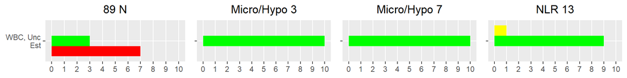

#### **WBC Differential, Class**

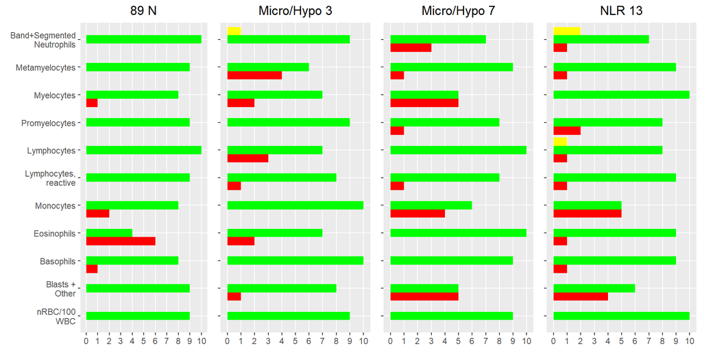

#### **WBC Morphology, Class**

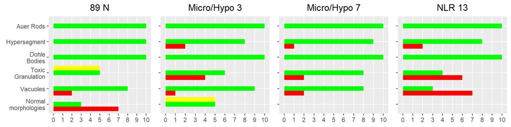

#### **WBC Comments, Class**

- 89 N
  - checked virtual slide had a lot less wbc than what i saw in lab
  - i found more bands than segmented neutrophils. bacterial infection is indictive to higher neutrophil count but the bands were abnormally high. seen a smudge cell
  - smudge cells are present
  - normal :)
  - NA
  - smudge cells (present)
  - 15% bands
  - NA
  - normal wbc morphology observed.
  - no nucleated rbc present.
- Micro/Hypo 3
  - n/a
  - NA
  - NA
  - no comments
  - NA
  - i was surprised to see a basophil so surprised actually that i forgot what they look like and had to look the cell up to classify it.
  - smudge cells were present. no nucleated rbc were present
  - this slide was evaluated from digital views available in d2l due to lack of time in the lab. toxic granulation seen in neutrophils appeared significant. some neutrophils appeared hypersegmented (although i’m open to clarification and correction. i am concerned about my estimates. it seems like i’m always 2 units below the actual counts.
  - so i was not sure if the one basophil was actually a toxic granulated segmented neutrophil but i had asked for second opinions from my peers in lab and they agreed it was a basophil. so i wanted to say that i am aware that it could possible have been a toxic granulated segmented neutrophil instead of a basophil. please let me know what you think.
  - toxic granulation seen
- Micro/Hypo 7
  - smudge cell present
  - super difficult to see any detail on online slides to determine maturity
  - NA
  - had a hard time seeing if any of the were granulated in terms of the lymph count etc. but i did my best!
  - NA
  - increased number of lymphocytes
  - smudge cells present
  - NA
  - smudge cells were present.
  - smudge cells present.
- NLR 13
  - artifacts and smudge cells. field 14 i wasnt sure how to classify the biggest purple cell.
  - hard to confirm viewing on computer
  - smudge cell present
  - smudge cells present.
  - i saw toxic granulation in segmented banded and metamyeloctyes. i also saw vacuoles present in both lymphocytes and neutrophils (segmented and banded).
  - NA
  - NA
  - NA
  - smudge cells present
  - a very high number of immature wbc cells were observed. hypersegmentation toxic granulation and vacuoles present in neutrophil population. smudge cells visible.

### **RBC**

#### **RBC Morphology, Class**

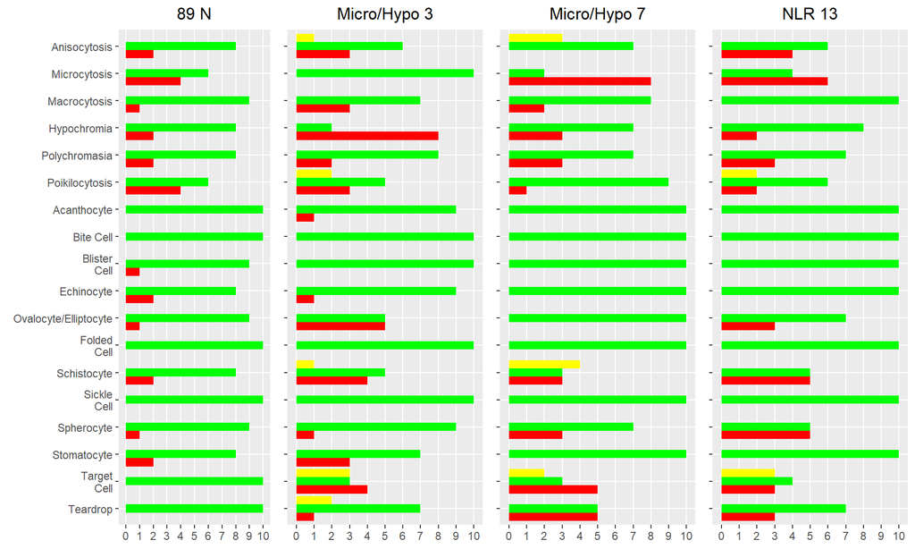

#### **RBC Other, Class**

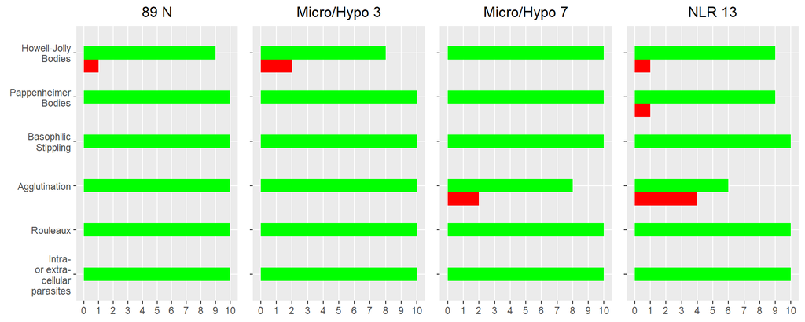

#### **RBC Comments, Class**

- 89 N
  - NA
  - i noticed a few teardrop cells schistocytes and some target cells but nothing significant to call.
  - normal rbc morphology observed.
  - n/a
  - the blood looked mostly normal some micro some macro but mostly normal sized rbc. mchc was barely in normal range.
  - NA
  - other morphologies were present such as bite cell and stomatocytes. however their quantities were not enough to call it.
  - NA
  - none
  - no comments
- Micro/Hypo 3
  - severly hopchromic
  - rbc appear very small and majority of them has a central parlor that is greater than 1/3
  - NA
  - n/a
  - NA
  - i called slight for the teardrop cells but i feel its bordering on slight and moderate but some of my frames only had 2 and some had exactly 4 so its definitely on the higher end of slight to maybe moderate. - i used fields 10-90 + 89
  - all rbc indice value were low for this patient besides rdw. most rbcs had more than 1/3 pallor which is indictive of the low hgbmchc. i did not think the cells were macrocytic but the rdw is leading me to believe that there are more macrocytic cells than what i seen. alot of the rbcs i seen were microcytic and spread out more than normal which is why the mcv and rbc value is low. i am hung up on the fact rdw is so large yet i hardly seen what i consider macrocytic.
  - mcv 67fl suggests microcytosis which was confirmed with slide evaluation. low hgb suggests hypochromia which was confirmed with slide evaluation. rdw was high at 19.2% which suggests anisocytosis and was confirmed as mdk with slide evaluation.
  - toxic granulation present
  - NA
- Micro/Hypo 7
  - n/a
  - NA
  - heavily mixed
  - marked anisocytosis with microcytic and normocytic rbc morphology. marked hypochromia and normochromia in rbc morphology.
  - i saw teardrops but i did not feel it was enough to call could be bordering on slight depending on which fields were picked but i do not think i would personally call it slight.
  - dimorphic rbc population observed.
  - no comments
  - NA
  - the rdw is really high i only found normal and micro rbcs.
  - NA
- NLR 13
  - NA
  - nothing to add
  - NA
  - this slide contained a very small mono layer due to marked microcytic population. moderate hypochromasia.
  - NA
  - none
  - i couldnt find any poikiloctyes only abnormally shaped cells. most of the rbc appear to have no center pallor which is weird since usually that would increase hgb content.
  - pappenheimer bodies present.
  - n/a
  - no comments

### **PLT**

#### **PLT Estimate, Class**

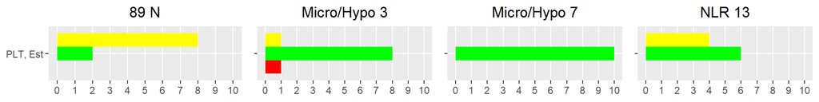

#### **PLT Morphology, Class**

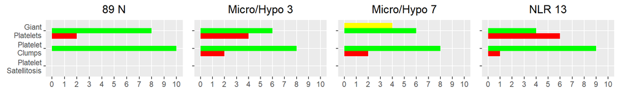

#### **PLT Comments, Class**

- 89 N
  - no abnormalities observed.
  - pretty average
  - NA
  - NA
  - multiple giant platelets seen
  - it is visually easier using the microscope. i think the virtual slides have a lot of gray spots that are not platelets.
  - no comments
  - n/a
  - normal platelet morphology observed.
  - NA
- Micro/Hypo 3
  - none
  - more than one giant plt present.
  - n/a
  - NA
  - seem some clumps
  - nothing to report here
  - NA
  - NA
  - plt estimate seems suspicious. based on histogram count is within normal range however the mpv shows wider curve although value is within normal range. please help me understand.
  - normal range just on the low side of the range
- Micro/Hypo 7
  - in the feathered edge had platelet clump
  - none
  - did see a few giant platelets
  - NA
  - n/a
  - no satellitism and hypogranular cells present
  - NA
  - giant plt present.
  - NA
  - my plt estimate is extremely high when compared to actual count and histogram. i’d like to be guided with this. i understand the concept however when i do it independently i am unsure of the estimate. in this case the plt count was not given but based on histogram the plt count is within normal range.
- NLR 13
  - giant plt present.
  - none
  - NA
  - nothing to add
  - NA
  - barely had normal platelet conc.
  - n/a
  - platelet estimate within normal range however histogram suggest below normal counts. plt count not provided by instrument.
  - no comments
  - NA